# Metagenomics Summary Report

Sample ID: `SRR606249_subset10`

May 30, 2019

```r
library(knitr)
library(tidyverse)
library(DT)
opts_chunk$set(echo=TRUE, warning=FALSE, message=FALSE)
theme_set(theme_bw())
```

# About

## About this report

This report pulls in statistics and reports generated after running all workflows as described in the version 1.2 wiki. Each major section (QA, taxonomic classification, assembly, functional annotation) is accessible via a link in the table of contents above. Tabs under each major heading expand to show summary results, links to further reports, details, or documentation on how these results were produced. Within particular tabs there are buttons that further subdivide results that are displayed (e.g., different assemblers, or different AMR tools).

## About this analysis

# Read Filtering

## General statistics

```r
read_tsv("SRR606249_subset10_fastqc_multiqc_report_data/multiqc_general_stats.txt") %>%
  set_names(~str_remove(., "FastQC_mqc-generalstats-")) %>%
  mutate_if(is.double, round, 2) %>%
  DT::datatable(caption="General QA statistics about samples in this run.")
```

|  | Sample | avg_sequence_length | percent_gc | percent_fails | total_sequences | percent_duplicates |
| --- | --- | --- | --- | --- | --- | --- |
| 1 | SRR606249_subset10_1_reads | 101 | 50 | 0 | 5400000 | 3.44 |
| 2 | SRR606249_subset10_2_reads | 101 | 49 | 0 | 5400000 | 3.49 |
| 3 | SRR606249_subset10_trim2_1 | 99.93 | 50 | 0 | 5337063 | 3.33 |
| 4 | SRR606249_subset10_trim2_2 | 99.89 | 49 | 0 | 5337063 | 3.29 |
| 5 | SRR606249_subset10_trim30_1 | 93.68 | 49 | 0 | 5044284 | 2.85 |
| 6 | SRR606249_subset10_trim30_2 | 92.41 | 49 | 0 | 5044284 | 2.97 |

```r
get_unique_kmers <- function(file) {
  read_lines(file) %>%
    grep("unique k-mers", ., value=TRUE) %>%
    str_extract("\\d+") %>%
    as.integer()
}
list.files(pattern="uniqueK\\d\\d\\.txt") %>%
  tibble(file=.) %>%
  mutate(sample=str_extract(file, ".+trim\\d+")) %>%
  mutate(K=str_extract(file, "K\\d+")) %>%
  mutate(number_unique_kmers=map_int(file, get_unique_kmers)) %>%
  select(-file) %>%
  mutate_if(is.integer, scales::comma) %>%
  DT::datatable(caption="Number of unique kmers in each sample in this run.")
```

|  | sample | K | number_unique_kmers |
| --- | --- | --- | --- |
| 1 | SRR606249_subset10_trim2 | K21 | 203,749,322 |
| 2 | SRR606249_subset10_trim2 | K31 | 201,383,388 |
| 3 | SRR606249_subset10_trim2 | K51 | 186,396,385 |
| 4 | SRR606249_subset10_trim30 | K21 | 170,724,835 |
| 5 | SRR606249_subset10_trim30 | K31 | 165,019,600 |
| 6 | SRR606249_subset10_trim30 | K51 | 148,673,196 |

## MultiQC Reports: FastQC

Click for links to comprehensive quality assessment reports:

```r
x <- list.files(pattern="fastqc_multiqc_report\\.html$")
glue::glue("- **[{x}]({x})**") %>%
  cat(sep="\n")
```

- **SRR606249_subset10_fastqc_multiqc_report.html**

## Detailed FastQC statistics

```r
read_tsv("SRR606249_subset10_fastqc_multiqc_report_data/multiqc_fastqc.txt") %>%
  DT::datatable(caption="Comprehensive information from FastQC (side-scroll to see more)", options = list(scrollX='600px'))
```

|  | Sample | Sequences flagged as poor quality | per_sequence_gc_content | per_base_n_content | per_base_sequence_quality | per_sequence_quality_scores | Filename | total_deduplicated_percentage | overrepresented_sequences | per_base_sequence_content | %GC | Total Sequences | basic_statistics | Sequence length | sequence_length_distribution | avg_sequence_length | File type | sequence_duplication_levels | Encoding | adapter_content |
| --- | --- | --- | --- | --- | --- | --- | --- | --- | --- | --- | --- | --- | --- | --- | --- | --- | --- | --- | --- | --- |
| 1 | SRR606249_subset10_1_reads | 0 | warn | pass | pass | pass | SRR606249_subset10_1_reads.fq.gz | 96.5594415838144 | pass | warn | 50 | 5400000 | pass | 101.0 | pass | 101 | Conventional base calls | pass | Sanger / Illumina 1.9 | pass |
| 2 | SRR606249_subset10_2_reads | 0 | warn | pass | pass | pass | SRR606249_subset10_2_reads.fq.gz | 96.5053901247476 | warn | warn | 49 | 5400000 | pass | 101.0 | pass | 101 | Conventional base calls | pass | Sanger / Illumina 1.9 | pass |
| 3 | SRR606249_subset10_trim2_1 | 0 | warn | pass | pass | pass | SRR606249_subset10_trim2_1.fq.gz | 96.6716576082551 | pass | warn | 50 | 5337063 | pass | 25-101 | warn | 99.9261331560073 | Conventional base calls | pass | Sanger / Illumina 1.9 | pass |
| 4 | SRR606249_subset10_trim2_2 | 0 | warn | pass | pass | pass | SRR606249_subset10_trim2_2.fq.gz | 96.7083384268681 | pass | warn | 49 | 5337063 | pass | 25-101 | warn | 99.8949602056412 | Conventional base calls | pass | Sanger / Illumina 1.9 | pass |
| 5 | SRR606249_subset10_trim30_1 | 0 | warn | pass | pass | pass | SRR606249_subset10_trim30_1.fq.gz | 97.1496193250422 | pass | warn | 49 | 5044284 | pass | 25-101 | warn | 93.6794597607906 | Conventional base calls | pass | Sanger / Illumina 1.9 | pass |
| 6 | SRR606249_subset10_trim30_2 | 0 | warn | pass | pass | pass | SRR606249_subset10_trim30_2.fq.gz | 97.0260156021679 | pass | warn | 49 | 5044284 | pass | 25-101 | warn | 92.4113606608986 | Conventional base calls | pass | Sanger / Illumina 1.9 | pass |

```r
read_tsv("SRR606249_subset10_fastqc_multiqc_report_data/multiqc_sources.txt") %>%
  DT::datatable(caption="MultiQC Data Sources")
```

|  | Module | Section | Sample Name | Source |
| --- | --- | --- | --- | --- |
| 1 | FastQC | all_sections | SRR606249_subset10_trim2_1 | /tmp/SRR606249_subset10_trim2_1_fastqc.zip |
| 2 | FastQC | all_sections | SRR606249_subset10_trim30_1 | /tmp/SRR606249_subset10_trim30_1_fastqc.zip |
| 3 | FastQC | all_sections | SRR606249_subset10_1_reads | //tmp/SRR606249_subset10_1_reads_fastqc.zip |
| 4 | FastQC | all_sections | SRR606249_subset10_trim30_2 | /tmp/SRR606249_subset10_trim30_2_fastqc.zip |
| 5 | FastQC | all_sections | SRR606249_subset10_2_reads | //tmp/SRR606249_subset10_2_reads_fastqc.zip |
| 6 | FastQC | all_sections | SRR606249_subset10_trim2_2 | /tmp/SRR606249_subset10_trim2_2_fastqc.zip |

## Procedure

# Taxonomic Classification

## Krona plots

### Links to existing HTML files

Click for links to krona diagrams:

```r
x <- list.files(pattern=".*krona.*html$")
glue::glue("- **[{x}]({x})**") %>%
  cat(sep="\n")
```

- **SRR606249_subset10_trim2.kaiju_genus_krona_filtered1_classified.html**
- **SRR606249_subset10_trim2.kaiju_genus_krona_filtered1_total.html**
- **SRR606249_subset10_trim2.kaiju_genus_krona.html**
- **SRR606249_subset10_trim2.kaiju_species_krona.html**
- **SRR606249_subset10_trim30.kaiju_genus_krona_filtered1_classified.html**
- **SRR606249_subset10_trim30.kaiju_genus_krona_filtered1_total.html**
- **SRR606249_subset10_trim30.kaiju_genus_krona.html**
- **SRR606249_subset10_trim30.kaiju_species_krona.html**

### Direct Krona embedding (experimental)

This is highly experimental. This shows a direct embedding of SRR606249_subset10_trim30.kaiju_species_krona.html.

[interactive chart not shown]

## Kaiju results

### Direct links to files

```r
# x <- list.files(pattern="kaiju.+out")
# utils:::format.object_size(file.size(x), unit="MB")
# glue::glue("- **[{x}]({x})**") %>%
#   cat(sep="\n")
```

```r
x <- list.files(pattern="kaiju.+summary$")
glue::glue("- **[{x}]({x})**") %>%
  cat(sep="\n")
```

- **SRR606249_subset10_trim2.kaiju_genus_filtered1_classified.summary**
- **SRR606249_subset10_trim2.kaiju_genus_filtered1_total.summary**
- **SRR606249_subset10_trim2.kaiju_genus.summary**
- **SRR606249_subset10_trim2.kaiju_out_species.summary**
- **SRR606249_subset10_trim30.kaiju_genus_filtered1_classified.summary**
- **SRR606249_subset10_trim30.kaiju_genus_filtered1_total.summary**
- **SRR606249_subset10_trim30.kaiju_genus.summary**
- **SRR606249_subset10_trim30.kaiju_out_species.summary**

## Sourmash Gather Detailed results

### Trim2 k=21

```r
read_csv("SRR606249_subset10_trim2_k21.gather_output.csv") %>%
  mutate_if(is.double, round, 2) %>%
  DT::datatable(caption="Sourmash Gather results for k=21 (side-scroll to see more)", options = list(scrollX='600px'))
```

|  | intersect_bp | f_orig_query | f_match | f_unique_to_query | f_unique_weighted | average_abund | name | filename | md5 |
| --- | --- | --- | --- | --- | --- | --- | --- | --- | --- |
| 1 | 6600000 | 0.03 | 1 | 0.03 | 0.09 | 11.3 | BX119912.1 Rhodopirellula baltica SH 1 complete genome | data/refseq-k21.sbt.json | 7f160cdfaaa1bd3cb9345dde78061521 |
| 2 | 5730000 | 0.03 | 0.83 | 0.03 | 0.02 | 3.12 | BA000019.2 Nostoc sp. PCC 7120 DNA, complete genome | data/refseq-k21.sbt.json | 49dcc05178ac72326de9646578f376e3 |
| 3 | 5400000 | 0.03 | 0.8 | 0.03 | 0.01 | 2.29 | CP000875.1 Herpetosiphon aurantiacus DSM 785, complete genome | data/refseq-k21.sbt.json | 83bd36beaea8594fb28d3e4e44fe563f |
| 4 | 5150000 | 0.03 | 0.84 | 0.03 | 0.01 | 2.39 | AE015928.1 Bacteroides thetaiotaomicron VPI-5482, complete genome | data/refseq-k21.sbt.json | 12cd55e54f72933ac8eb37ca369663bd |
| 5 | 5000000 | 0.02 | 1 | 0.02 | 0.04 | 6.95 | AP009153.1 Gemmatimonas aurantiaca T-27 DNA, complete genome | data/refseq-k21.sbt.json | c35c32df9d43c14ed9f81e35f2331e06 |
| 6 | 4730000 | 0.02 | 0.5 | 0.02 | 0.01 | 1.65 | CP000270.1 Burkholderia xenovorans LB400 chromosome 1, complete sequence | data/refseq-k21.sbt.json | c7a74b6e204c56a29a67582e3003c4d5 |
| 7 | 4360000 | 0.02 | 0.91 | 0.02 | 0.02 | 3.1 | CP001364.1 Chloroflexus sp. Y-400-fl, complete genome | data/refseq-k21.sbt.json | c63bdc8ad8823143c2bb0fc05536cdd9 |
| 8 | 4080000 | 0.02 | 0.99 | 0.02 | 0.03 | 6.4 | CP001472.1 Acidobacterium capsulatum ATCC 51196, complete genome | data/refseq-k21.sbt.json | 4eef1714ac63252d3b183be5fa37ea57 |
| 9 | 3970000 | 0.02 | 0.73 | 0.02 | 0.01 | 2.49 | CP000850.1 Salinispora arenicola CNS-205, complete genome | data/refseq-k21.sbt.json | 181a22864d94d8556d60def06b382102 |
| 10 | 3940000 | 0.02 | 1 | 0.02 | 0.05 | 10.29 | CH959317.1 Sulfitobacter sp. NAS-14.1 scf_1099451320472 genomic scaffold, whole genome shotgun sequence | data/refseq-k21.sbt.json | 6ccfc2298d432314844cae985cabcff6 |

[output cut: 64 more lines]

### Trim2 k=31

```r
read_csv("SRR606249_subset10_trim2_k31.gather_output.csv") %>%
  mutate_if(is.double, round, 2) %>%
  DT::datatable(caption="Sourmash Gather results for k=31 (side-scroll to see more)", options = list(scrollX='600px'))
```

|  | intersect_bp | f_orig_query | f_match | f_unique_to_query | f_unique_weighted | average_abund | name | filename | md5 |
| --- | --- | --- | --- | --- | --- | --- | --- | --- | --- |
| 1 | 6830000 | 0.03 | 1 | 0.03 | 0.09 | 9.61 | BX119912.1 Rhodopirellula baltica SH 1 complete genome | data/refseq-k31.sbt.json | fe2f7e3e143e72582f902ff258901d47 |
| 2 | 6540000 | 0.03 | 0.83 | 0.03 | 0.03 | 2.91 | BA000019.2 Nostoc sp. PCC 7120 DNA, complete genome | data/refseq-k31.sbt.json | b707f3cdca627cd3c985ada91454874e |
| 3 | 5060000 | 0.02 | 0.8 | 0.02 | 0.01 | 2.09 | CP000875.1 Herpetosiphon aurantiacus DSM 785, complete genome | data/refseq-k31.sbt.json | e04a17715259ffe539c22d2f480a2484 |
| 4 | 4770000 | 0.02 | 0.77 | 0.02 | 0.01 | 2.13 | AE015928.1 Bacteroides thetaiotaomicron VPI-5482, complete genome | data/refseq-k31.sbt.json | 8affae43de8758c8d77c302cacc884ab |
| 5 | 4670000 | 0.02 | 0.89 | 0.02 | 0.02 | 2.76 | CP000909.1 Chloroflexus aurantiacus J-10-fl, complete genome | data/refseq-k31.sbt.json | 6cf63ffd3b4cdd74285f8c2ea5c04d78 |
| 6 | 4460000 | 0.02 | 0.99 | 0.02 | 0.04 | 6.16 | AP009153.1 Gemmatimonas aurantiaca T-27 DNA, complete genome | data/refseq-k31.sbt.json | ea5b483d89c2834cba889470ee54bc06 |
| 7 | 4250000 | 0.02 | 0.99 | 0.02 | 0.03 | 5.58 | CP001472.1 Acidobacterium capsulatum ATCC 51196, complete genome | data/refseq-k31.sbt.json | 53ae51540690b8114e8c9b1de15ac31f |
| 8 | 4060000 | 0.02 | 0.44 | 0.02 | 0.01 | 1.56 | CP000270.1 Burkholderia xenovorans LB400 chromosome 1, complete sequence | data/refseq-k31.sbt.json | 00ba560c11b5aed2491ac8a484d4e210 |
| 9 | 4050000 | 0.02 | 0.71 | 0.02 | 0.01 | 2.19 | CP000850.1 Salinispora arenicola CNS-205, complete genome | data/refseq-k31.sbt.json | 9cd58999b3384a98ae6e1c6d42918dff |
| 10 | 3890000 | 0.02 | 0.74 | 0.02 | 0.01 | 1.85 | AE010299.1 Methanosarcina acetivorans str. C2A, complete genome | data/refseq-k31.sbt.json | 5a9fc0ee959336a305ee239f9b66b7b9 |

[output cut: 64 more lines]

### Trim2 k=51

```r
read_csv("SRR606249_subset10_trim2_k51.gather_output.csv") %>%
  mutate_if(is.double, round, 2) %>%
  DT::datatable(caption="Sourmash Gather results for k=51 (side-scroll to see more)", options = list(scrollX='600px'))
```

|  | intersect_bp | f_orig_query | f_match | f_unique_to_query | f_unique_weighted | average_abund | name | filename | md5 |
| --- | --- | --- | --- | --- | --- | --- | --- | --- | --- |
| 1 | 7420000 | 0.04 | 0.99 | 0.04 | 0.09 | 6.69 | BX119912.1 Rhodopirellula baltica SH 1 complete genome | data/refseq-k51.sbt.json | 0158c8fed04b7805bd8b6c9b1deb0457 |
| 2 | 5270000 | 0.03 | 0.72 | 0.03 | 0.02 | 2.46 | BA000019.2 Nostoc sp. PCC 7120 DNA, complete genome | data/refseq-k51.sbt.json | 65dee47a2f5d0719c93a0f14398574d4 |
| 3 | 4530000 | 0.02 | 0.64 | 0.02 | 0.02 | 1.83 | CP000875.1 Herpetosiphon aurantiacus DSM 785, complete genome | data/refseq-k51.sbt.json | d5fb91a1945683fed1128ce3a59570eb |
| 4 | 4350000 | 0.02 | 0.78 | 0.02 | 0.02 | 2.24 | CP000909.1 Chloroflexus aurantiacus J-10-fl, complete genome | data/refseq-k51.sbt.json | 8f4d200ad2557c0da2a57913c21c0354 |
| 5 | 4240000 | 0.02 | 0.96 | 0.02 | 0.03 | 4.18 | AP009153.1 Gemmatimonas aurantiaca T-27 DNA, complete genome | data/refseq-k51.sbt.json | d39f70f284ac206dee2ee61b8a680a8b |
| 6 | 4060000 | 0.02 | 0.96 | 0.02 | 0.03 | 4.19 | CP001472.1 Acidobacterium capsulatum ATCC 51196, complete genome | data/refseq-k51.sbt.json | 25e2ad37d2f90d5d6ed8ec0521b7a059 |
| 7 | 4000000 | 0.02 | 0.66 | 0.02 | 0.01 | 1.87 | AE015928.1 Bacteroides thetaiotaomicron VPI-5482, complete genome | data/refseq-k51.sbt.json | 0b4c0b9a93b1998725462732d6b6a016 |
| 8 | 3840000 | 0.02 | 0.96 | 0.02 | 0.04 | 5.6 | CH959317.1 Sulfitobacter sp. NAS-14.1 scf_1099451320472 genomic scaffold, whole genome shotgun sequence | data/refseq-k51.sbt.json | 4191f9193be96dbebba5ebaabc75dcf1 |
| 9 | 3770000 | 0.02 | 0.96 | 0.02 | 0.03 | 3.71 | AE017180.2 Geobacter sulfurreducens PCA, complete genome | data/refseq-k51.sbt.json | d1c43766838dfffdefe2cf17d0742d12 |
| 10 | 3510000 | 0.02 | 0.61 | 0.02 | 0.01 | 1.77 | CP000850.1 Salinispora arenicola CNS-205, complete genome | data/refseq-k51.sbt.json | 9429201e056e9e0f78ac9d9594289e82 |

[output cut: 65 more lines]

### Trim30 k=21

```r
read_csv("SRR606249_subset10_trim30_k21.gather_output.csv") %>%
  mutate_if(is.double, round, 2) %>%
  DT::datatable(caption="Sourmash Gather results for k=21 (side-scroll to see more)", options = list(scrollX='600px'))
```

|  | intersect_bp | f_orig_query | f_match | f_unique_to_query | f_unique_weighted | average_abund | name | filename | md5 |
| --- | --- | --- | --- | --- | --- | --- | --- | --- | --- |
| 1 | 6600000 | 0.04 | 1 | 0.04 | 0.09 | 9.97 | BX119912.1 Rhodopirellula baltica SH 1 complete genome | data/refseq-k21.sbt.json | 7f160cdfaaa1bd3cb9345dde78061521 |
| 2 | 5530000 | 0.03 | 0.8 | 0.03 | 0.02 | 2.98 | BA000019.2 Nostoc sp. PCC 7120 DNA, complete genome | data/refseq-k21.sbt.json | 49dcc05178ac72326de9646578f376e3 |
| 3 | 5210000 | 0.03 | 0.77 | 0.03 | 0.02 | 2.2 | CP000875.1 Herpetosiphon aurantiacus DSM 785, complete genome | data/refseq-k21.sbt.json | 83bd36beaea8594fb28d3e4e44fe563f |
| 4 | 5000000 | 0.03 | 0.82 | 0.03 | 0.02 | 2.27 | AE015928.1 Bacteroides thetaiotaomicron VPI-5482, complete genome | data/refseq-k21.sbt.json | 12cd55e54f72933ac8eb37ca369663bd |
| 5 | 4930000 | 0.03 | 0.98 | 0.03 | 0.04 | 5.79 | AP009153.1 Gemmatimonas aurantiaca T-27 DNA, complete genome | data/refseq-k21.sbt.json | c35c32df9d43c14ed9f81e35f2331e06 |
| 6 | 4170000 | 0.02 | 0.87 | 0.02 | 0.02 | 2.84 | CP001364.1 Chloroflexus sp. Y-400-fl, complete genome | data/refseq-k21.sbt.json | c63bdc8ad8823143c2bb0fc05536cdd9 |
| 7 | 4140000 | 0.02 | 0.44 | 0.02 | 0.01 | 1.56 | CP000270.1 Burkholderia xenovorans LB400 chromosome 1, complete sequence | data/refseq-k21.sbt.json | c7a74b6e204c56a29a67582e3003c4d5 |
| 8 | 4050000 | 0.02 | 0.99 | 0.02 | 0.03 | 5.6 | CP001472.1 Acidobacterium capsulatum ATCC 51196, complete genome | data/refseq-k21.sbt.json | 4eef1714ac63252d3b183be5fa37ea57 |
| 9 | 3940000 | 0.02 | 1 | 0.02 | 0.05 | 8.77 | CH959317.1 Sulfitobacter sp. NAS-14.1 scf_1099451320472 genomic scaffold, whole genome shotgun sequence | data/refseq-k21.sbt.json | 6ccfc2298d432314844cae985cabcff6 |
| 10 | 3780000 | 0.02 | 0.97 | 0.02 | 0.03 | 5.21 | AE017180.2 Geobacter sulfurreducens PCA, complete genome | data/refseq-k21.sbt.json | 4176760dfc22f8fbbba7f7c3326a3c22 |

[output cut: 64 more lines]

### Trim30 k=31

```r
read_csv("SRR606249_subset10_trim30_k31.gather_output.csv") %>%
  mutate_if(is.double, round, 2) %>%
  DT::datatable(caption="Sourmash Gather results for k=31 (side-scroll to see more)", options = list(scrollX='600px'))
```

|  | intersect_bp | f_orig_query | f_match | f_unique_to_query | f_unique_weighted | average_abund | name | filename | md5 |
| --- | --- | --- | --- | --- | --- | --- | --- | --- | --- |
| 1 | 6820000 | 0.04 | 1 | 0.04 | 0.09 | 8.37 | BX119912.1 Rhodopirellula baltica SH 1 complete genome | data/refseq-k31.sbt.json | fe2f7e3e143e72582f902ff258901d47 |
| 2 | 6330000 | 0.04 | 0.8 | 0.04 | 0.03 | 2.82 | BA000019.2 Nostoc sp. PCC 7120 DNA, complete genome | data/refseq-k31.sbt.json | b707f3cdca627cd3c985ada91454874e |
| 3 | 4780000 | 0.03 | 0.76 | 0.03 | 0.01 | 1.97 | CP000875.1 Herpetosiphon aurantiacus DSM 785, complete genome | data/refseq-k31.sbt.json | e04a17715259ffe539c22d2f480a2484 |
| 4 | 4600000 | 0.03 | 0.75 | 0.03 | 0.01 | 2.05 | AE015928.1 Bacteroides thetaiotaomicron VPI-5482, complete genome | data/refseq-k31.sbt.json | 8affae43de8758c8d77c302cacc884ab |
| 5 | 4410000 | 0.03 | 0.84 | 0.03 | 0.02 | 2.5 | CP000909.1 Chloroflexus aurantiacus J-10-fl, complete genome | data/refseq-k31.sbt.json | 6cf63ffd3b4cdd74285f8c2ea5c04d78 |
| 6 | 4370000 | 0.03 | 0.97 | 0.03 | 0.03 | 5.06 | AP009153.1 Gemmatimonas aurantiaca T-27 DNA, complete genome | data/refseq-k31.sbt.json | ea5b483d89c2834cba889470ee54bc06 |
| 7 | 4180000 | 0.02 | 0.97 | 0.02 | 0.03 | 4.81 | CP001472.1 Acidobacterium capsulatum ATCC 51196, complete genome | data/refseq-k31.sbt.json | 53ae51540690b8114e8c9b1de15ac31f |
| 8 | 3800000 | 0.02 | 0.97 | 0.02 | 0.04 | 7.44 | CH959317.1 Sulfitobacter sp. NAS-14.1 scf_1099451320472 genomic scaffold, whole genome shotgun sequence | data/refseq-k31.sbt.json | 5d89b30ca0135902efc54d4dfef06c07 |
| 9 | 3750000 | 0.02 | 0.71 | 0.02 | 0.01 | 1.79 | AE010299.1 Methanosarcina acetivorans str. C2A, complete genome | data/refseq-k31.sbt.json | 5a9fc0ee959336a305ee239f9b66b7b9 |
| 10 | 3670000 | 0.02 | 0.7 | 0.02 | 0.01 | 1.76 | CP000139.1 Bacteroides vulgatus ATCC 8482, complete genome | data/refseq-k31.sbt.json | c2a9fe2dfaa14f88998b7d1dabc05f46 |

[output cut: 64 more lines]

### Trim30 k=51

```r
read_csv("SRR606249_subset10_trim30_k51.gather_output.csv") %>%
  mutate_if(is.double, round, 2) %>%
  DT::datatable(caption="Sourmash Gather results for k=51 (side-scroll to see more)", options = list(scrollX='600px'))
```

|  | intersect_bp | f_orig_query | f_match | f_unique_to_query | f_unique_weighted | average_abund | name | filename | md5 |
| --- | --- | --- | --- | --- | --- | --- | --- | --- | --- |
| 1 | 7340000 | 0.05 | 0.98 | 0.05 | 0.09 | 5.72 | BX119912.1 Rhodopirellula baltica SH 1 complete genome | data/refseq-k51.sbt.json | 0158c8fed04b7805bd8b6c9b1deb0457 |
| 2 | 5050000 | 0.03 | 0.69 | 0.03 | 0.03 | 2.32 | BA000019.2 Nostoc sp. PCC 7120 DNA, complete genome | data/refseq-k51.sbt.json | 65dee47a2f5d0719c93a0f14398574d4 |
| 3 | 4230000 | 0.03 | 0.6 | 0.03 | 0.02 | 1.72 | CP000875.1 Herpetosiphon aurantiacus DSM 785, complete genome | data/refseq-k51.sbt.json | d5fb91a1945683fed1128ce3a59570eb |
| 4 | 3970000 | 0.03 | 0.9 | 0.03 | 0.03 | 3.36 | AP009153.1 Gemmatimonas aurantiaca T-27 DNA, complete genome | data/refseq-k51.sbt.json | d39f70f284ac206dee2ee61b8a680a8b |
| 5 | 3900000 | 0.03 | 0.92 | 0.03 | 0.03 | 3.56 | CP001472.1 Acidobacterium capsulatum ATCC 51196, complete genome | data/refseq-k51.sbt.json | 25e2ad37d2f90d5d6ed8ec0521b7a059 |
| 6 | 3900000 | 0.03 | 0.7 | 0.03 | 0.02 | 2.04 | CP000909.1 Chloroflexus aurantiacus J-10-fl, complete genome | data/refseq-k51.sbt.json | 8f4d200ad2557c0da2a57913c21c0354 |
| 7 | 3820000 | 0.03 | 0.63 | 0.03 | 0.02 | 1.8 | AE015928.1 Bacteroides thetaiotaomicron VPI-5482, complete genome | data/refseq-k51.sbt.json | 0b4c0b9a93b1998725462732d6b6a016 |
| 8 | 3730000 | 0.02 | 0.93 | 0.02 | 0.04 | 4.57 | CH959317.1 Sulfitobacter sp. NAS-14.1 scf_1099451320472 genomic scaffold, whole genome shotgun sequence | data/refseq-k51.sbt.json | 4191f9193be96dbebba5ebaabc75dcf1 |
| 9 | 3520000 | 0.02 | 0.89 | 0.02 | 0.02 | 3.12 | AE017180.2 Geobacter sulfurreducens PCA, complete genome | data/refseq-k51.sbt.json | d1c43766838dfffdefe2cf17d0742d12 |
| 10 | 3120000 | 0.02 | 0.58 | 0.02 | 0.01 | 1.5 | AE010299.1 Methanosarcina acetivorans str. C2A, complete genome | data/refseq-k51.sbt.json | 130c04e39dcd6f64ce342349a618f397 |

[output cut: 65 more lines]

## Procedure

# Assembly

## General statistics

### MEGAHIT

```r
read_tsv("SRR606249_subset10.megahit_multiqc_report_data/multiqc_general_stats.txt") %>%
  set_names(~str_remove(., "QUAST_mqc-generalstats-")) %>%
  select(Sample, Total_length, N50) %>%
  DT::datatable(caption="General assembly statistics about samples in this run from MEGAHIT.")
```

|  | Sample | Total_length | N50 |
| --- | --- | --- | --- |
| 1 | SRR606249_subset10_trim2.megahit.contigs | 109606033 | 2884 |
| 2 | SRR606249_subset10_trim30.megahit.contigs | 97195147 | 2434 |

### MetaSPADES

```r
read_tsv("SRR606249_subset10.metaspades_multiqc_report_data/multiqc_general_stats.txt") %>%
  set_names(~str_remove(., "QUAST_mqc-generalstats-")) %>%
  select(Sample, Total_length, N50) %>%
  DT::datatable(caption="General assembly statistics about samples in this run from MetaSPADES.")
```

|  | Sample | Total_length | N50 |
| --- | --- | --- | --- |
| 1 | SRR606249_subset10_trim2.metaspades.contigs | 114623467 | 2643 |
| 2 | SRR606249_subset10_trim30.metaspades.contigs | 103089075 | 2324 |

## QUAST

### MultiQC reports

Click for links to comprehensive quality assessment reports:

```r
x <- list.files(pattern="(megahit|metaspades)_multiqc_report\\.html$")
glue::glue("- **[{x}]({x})**") %>%
  cat(sep="\n")
```

- **SRR606249_subset10.megahit_multiqc_report.html**
- **SRR606249_subset10.metaspades_multiqc_report.html**

### Individual QUAST reports

Individual QUAST reports:

```r
x <- list.files(pattern="^report\\.html$", recursive=TRUE)
glue::glue("- **[{x}]({x})**") %>%
  cat(sep="\n")
```

- **SRR606249_subset10_trim2.megahit_quast/report.html**
- **SRR606249_subset10_trim2.metaspades_quast/report.html**
- **SRR606249_subset10_trim30.megahit_quast/report.html**
- **SRR606249_subset10_trim30.metaspades_quast/report.html**

## Detailed results

### MEGAHIT

```r
read_tsv("SRR606249_subset10.megahit_multiqc_report_data/multiqc_quast.txt") %>%
  DT::datatable(caption="Comprehensive information from QUAST (side-scroll to see more)", options = list(scrollX='600px'))
```

|  | Sample | Total length (>= 0 bp) | # contigs | Largest contig | # contigs (>= 5000 bp) | # contigs (>= 25000 bp) | Total length (>= 50000 bp) | N75 | # contigs (>= 10000 bp) | N50 | L50 | Total length (>= 5000 bp) | # N's per 100 kbp | # contigs (>= 1000 bp) | # contigs (>= 50000 bp) | GC (%) | Total length (>= 1000 bp) | Total length | # contigs (>= 0 bp) | Total length (>= 10000 bp) | L75 | Total length (>= 25000 bp) |
| --- | --- | --- | --- | --- | --- | --- | --- | --- | --- | --- | --- | --- | --- | --- | --- | --- | --- | --- | --- | --- | --- | --- |
| 1 | SRR606249_subset10_trim2.megahit.contigs | 127602974 | 61775 | 264437 | 3192 | 327 | 8499140 | 1062 | 1305 | 2884 | 6128 | 43878763 | 0 | 24957 | 98 | 49.65 | 84237459 | 109606033 | 108640 | 30827601 | 22984 | 16313625 |
| 2 | SRR606249_subset10_trim30.megahit.contigs | 115429318 | 58955 | 212072 | 2756 | 251 | 4193339 | 998 | 1037 | 2434 | 7035 | 34226320 | 0 | 23530 | 56 | 48.8 | 72859770 | 97195147 | 106498 | 22486538 | 23567 | 10798898 |

### MetaSPADES

```r
read_tsv("SRR606249_subset10.metaspades_multiqc_report_data/multiqc_quast.txt") %>%
  DT::datatable(caption="Comprehensive information from QUAST (side-scroll to see more)", options = list(scrollX='600px'))
```

|  | Sample | # contigs (>= 5000 bp) | Total length (>= 50000 bp) | Total length (>= 25000 bp) | Total length | Total length (>= 10000 bp) | Total length (>= 1000 bp) | N50 | GC (%) | # contigs (>= 25000 bp) | L50 | # N's per 100 kbp | Largest contig | L75 | # contigs (>= 0 bp) | # contigs (>= 10000 bp) | Total length (>= 0 bp) | N75 | # contigs (>= 50000 bp) | # contigs (>= 1000 bp) | # contigs | Total length (>= 5000 bp) |
| --- | --- | --- | --- | --- | --- | --- | --- | --- | --- | --- | --- | --- | --- | --- | --- | --- | --- | --- | --- | --- | --- | --- |
| 1 | SRR606249_subset10_trim2.metaspades.contigs | 3072 | 10040951 | 17715767 | 114623467 | 31598052 | 86531689 | 2643 | 49.62 | 340 | 6830 | 0 | 221137 | 25687 | 176205 | 1276 | 149130610 | 1014 | 117 | 26247 | 67101 | 43999551 |
| 2 | SRR606249_subset10_trim30.metaspades.contigs | 2735 | 5529178 | 12489985 | 103089075 | 24077498 | 76295676 | 2324 | 48.77 | 272 | 7609 | 0 | 220860 | 25813 | 174415 | 1049 | 137857497 | 972 | 72 | 24777 | 63812 | 35581121 |

## Procedure

# Comparison

## CSVs

```r
x <- list.files(pattern="read_assembly_comparison", recursive=FALSE)
glue::glue("- **[{x}]({x})**") %>%
  cat(sep="\n")
```

- **SRR606249_subset10andSRR606249_subset10_read_assembly_comparison.k21.csv**
- **SRR606249_subset10andSRR606249_subset10_read_assembly_comparison.k31.csv**
- **SRR606249_subset10andSRR606249_subset10_read_assembly_comparison.k51.csv**

## PNGs

### Direct links to images

```r
x <- list.files(pattern="read_assembly_comparison.+\\.png$", recursive=TRUE)
bx <- basename(x)
glue::glue("- **[{bx}]({x})**") %>%
  cat(sep="\n")
```

- **SRR606249_subset10andSRR606249_subset10_read_assembly_comparison.k21.png**
- **SRR606249_subset10andSRR606249_subset10_read_assembly_comparison.k31.png**
- **SRR606249_subset10andSRR606249_subset10_read_assembly_comparison.k51.png**

### Inline graphics (in the same order as above)

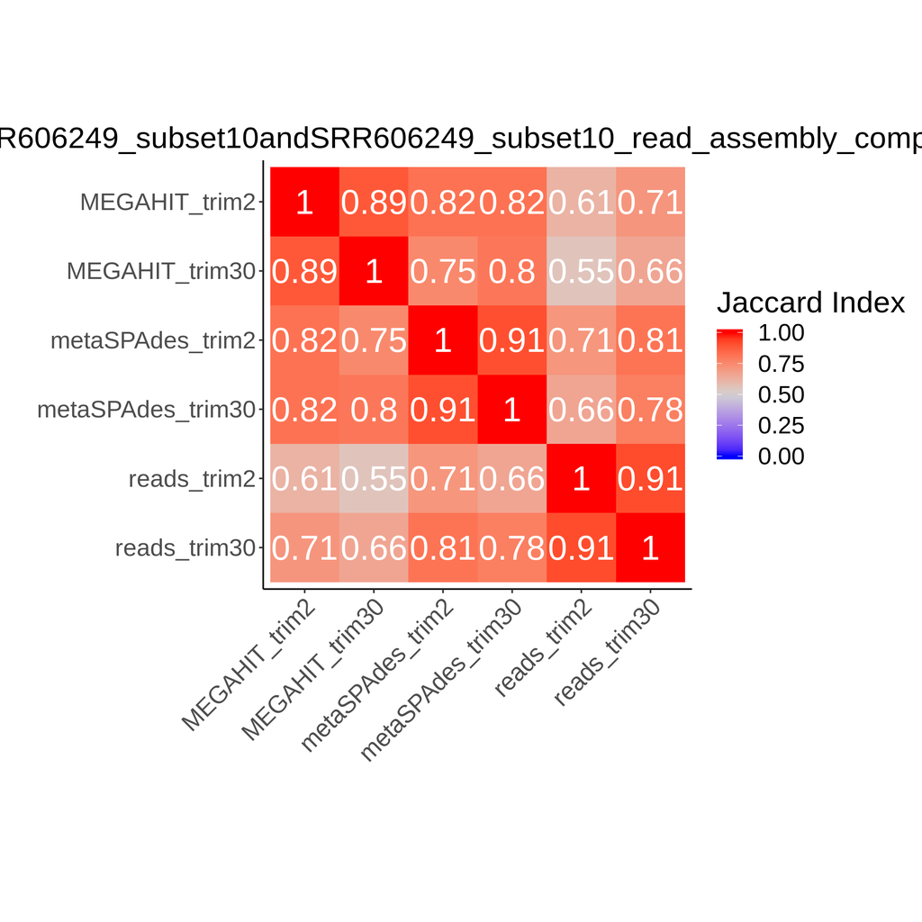

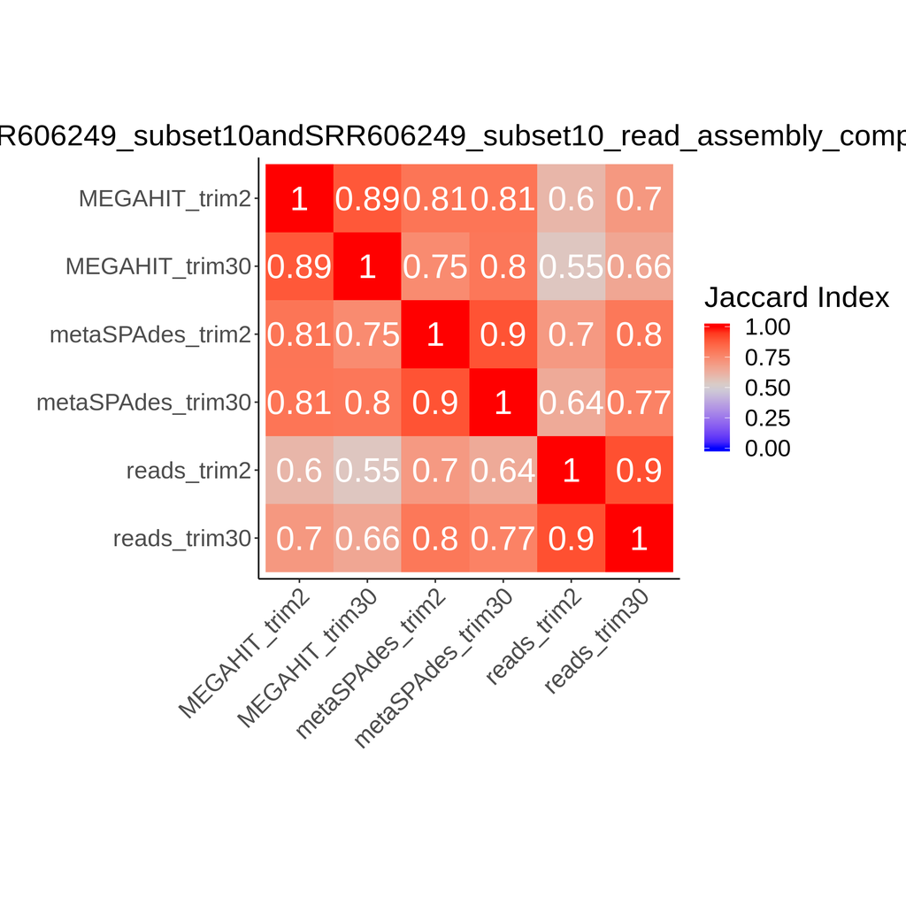

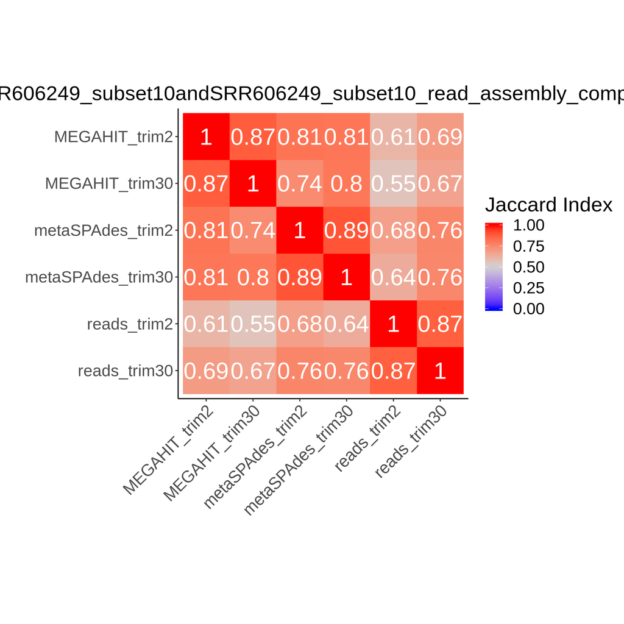

```r
knitr::include_graphics(x)
```

## Procedure

# Functional Inference

## Prokka

Click below to access prokka results:

```r
x <- list.files(pattern="podar_metaG_sbu.tsv", recursive=TRUE)
glue::glue("- **[{x}]({x})**") %>%
  cat(sep="\n")
```

- **SRR606249_subset10_trim2_megahit.prokka_annotation/podar_metaG_sbu.tsv**
- **SRR606249_subset10_trim2_metaspades.prokka_annotation/podar_metaG_sbu.tsv**
- **SRR606249_subset10_trim30_megahit.prokka_annotation/podar_metaG_sbu.tsv**
- **SRR606249_subset10_trim30_metaspades.prokka_annotation/podar_metaG_sbu.tsv**

## Antibiotic resistance

### Abricate (contigs)

```r
x <- list.files(pattern="card\\.csv$")
glue::glue("- **[{x}]({x})**") %>%
  cat(sep="\n")
```

- **SRR606249_subset10_trim2_megahit.abricate_card.csv**
- **SRR606249_subset10_trim2_metaspades.abricate_card.csv**
- **SRR606249_subset10_trim30_megahit.abricate_card.csv**
- **SRR606249_subset10_trim30_metaspades.abricate_card.csv**

### SRST2 (reads)

```r
x <- list.files(pattern="srst2.*results\\.txt$")
glue::glue("- **[{x}]({x})**") %>%
  cat(sep="\n")
```

- **SRR606249_subset10_trim2_ARGannot.r3.fasta.srst2__fullgenes__ARGannot.r3__results.txt**
- **SRR606249_subset10_trim2_ARGannot.r3.fasta.srst2__genes__ARGannot.r3__results.txt**
- **SRR606249_subset10_trim30_ARGannot.r3.fasta.srst2__fullgenes__ARGannot.r3__results.txt**
- **SRR606249_subset10_trim30_ARGannot.r3.fasta.srst2__genes__ARGannot.r3__results.txt**